# Exploration of Physical Activity Data by Nivedita Bijlani

We therefore understand from the above graphs that individuals who are separated, regardless of gender, age or activity levels, have similar likelihood of being obese or not. There will be more than physiological factors at play here, presumably difficult life situations.

[figure not shown]

Our next plot charts hdl by age, gender and activity level. A high hdl is responsible for a healthy heart. We noted earlier that as hdl goes up, bmi levels get lower. We also saw that 5 times more females have healthier hdl levels than males

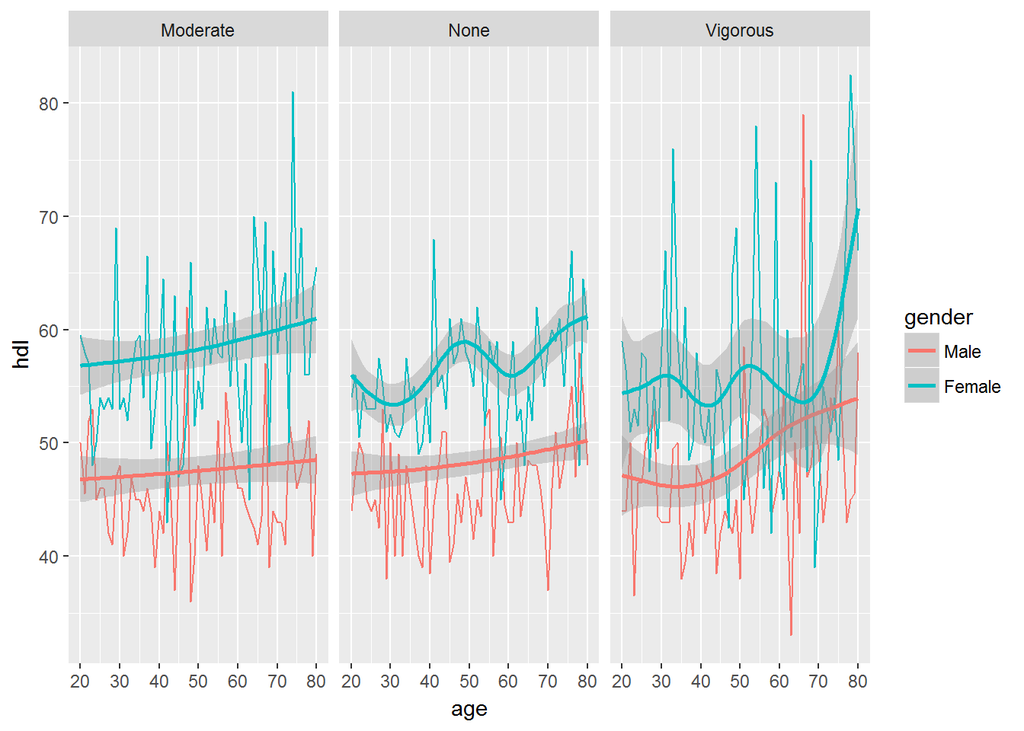

Do we see any differences with recreational activity patterns?

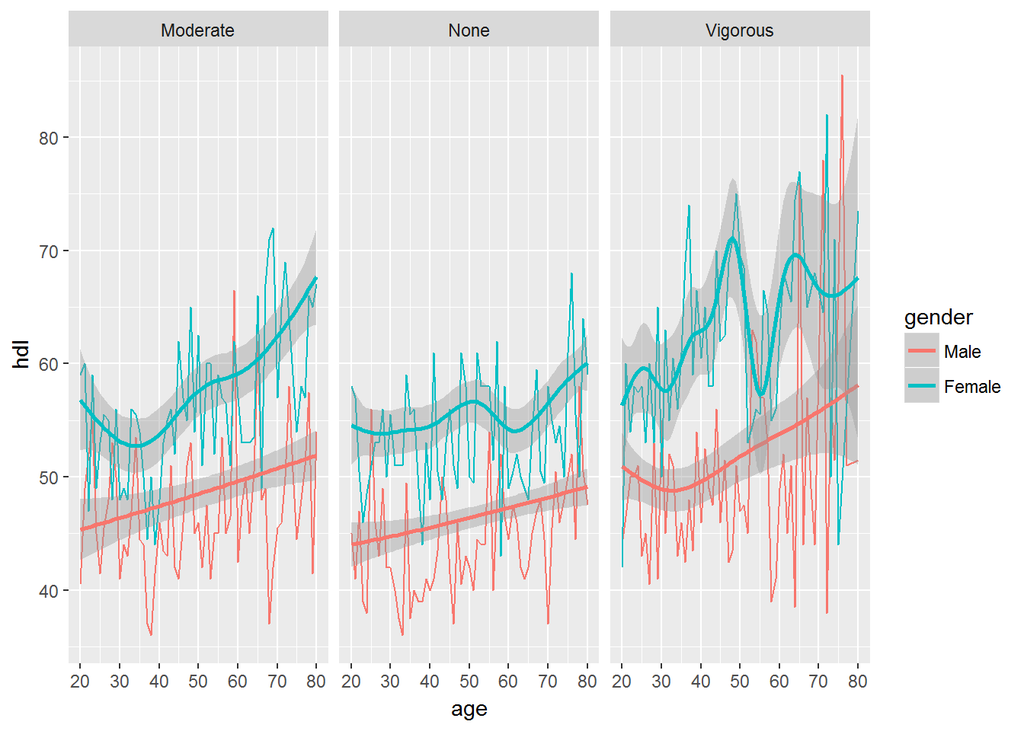